# ISM

## Concept of Interpretive Structural Modelling

ISM is the process of collaborating distinct or related essentials into a simplified and an organized format. Hence, ISM is a methodology that seeks the interrelationships among the various elements considered and endows with a hierarchal and multilevel structure. This imperative technique contributes to the managers, researchers and to individuals by converting the distorted web of elements into an understandable, readable and well-defined model (structure).

### Purpose of making ISM package

ISM, can be said to be a computer assisted interactive learning process and a way out by which a modelling group and its management can understand the complexity of relationship amongst attributes more accurately and precisely. Increasing popularity and usage of ISM technique has rejuvenated us to automate the working of ISM into a programme (or package “ISM”) that would be beneficial and encouraging for researchers, practitioners, managers and for other users.

Some of the benefits of the present framework can be described as follows:

1. ‘n’ numbers of parameters can be selected to analyse the interrelationship of any project/study
2. Eradication human errors in applying transitivity law or applying any other operation in solving problem
3. Can save precious time of users; and
4. Provides well-formatted and readable excel output files that make interpretation easier.

### Example

steps to run the package:

1. Install the package.
2. Select fname (a matrix of 0’s and 1’s) and Dir=getwd() or a path (where one wants to save output files) as parameters.
- ISM(fname=matrix(c(1,1,1,1,1,0,1,1,1,1,0,0,1,0,0,0,1,1,1,1,0,1,1,0,1),5,5,byrow=T), Dir = getwd())

*Generated Output*:-

[1] “/ISM/ISM_Matrix.xlsx”

[1] “/ISM/ISM_Output.xlsx”

[1] “Outputs have been created”

*Resulting Outputs (in Excel Formats)*

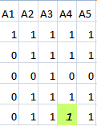

ISM_Matrix

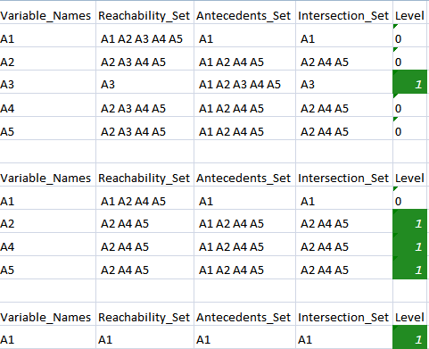

ISM_Output

For more details.

*Reference:* Adarsh Anand, Gunjan Bansal, (2017) “Interpretive structural modelling for attributes of software quality”, Journal of Advances in Management Research, Vol. 14 Issue: 3, pp.256-269, https://doi.org/10.1108/JAMR-11-2016-0097